# The West of England Wildlife Index

**Overview**

The West of England Wildlife Index aims to understand how animal populations are changing in our region. By modelling counts of organisms surveyed between the year 2000 and 2025, we can assess the abundance of different populations and how they may be changing over time. Abundance is a key aspect of biodiversity and understanding how it’s changing will help us conserve and protect nature in our region.

**Our initial results highlight three findings:**

- Firstly, the overall trajectory of bird populations is strongly negative (-18.3% per decade).
- Secondly, many groups have large uncertainty in their trends and species within those groups vary a lot from each other.
- Thirdly, there is a serious data gap for many organisms that is critical to fill through monitoring and community science.

**Get Involved:** If you would like to help monitor wildlife in the West of England please see our webpage to find out how you can get involved https://www.westofengland-ca.gov.uk/what-we-do/environment/nature-recovery/wildlife-index/.

**Trends by Class of Animal**

[interactive chart not shown]

| Taxa | Median % change per decade | Lower % change per decade | Upper % change per decade |
| --- | --- | --- | --- |
| All Species | -8.1 | -11.1 | -5.9 |
| Birds | -18.3 | -25.5 | -12.5 |
| Fishes | -10.6 | -33.5 | 27.5 |
| Insects | -5.3 | -13.8 | 5.0 |
| Mammals | 5.1 | -17.8 | 32.8 |

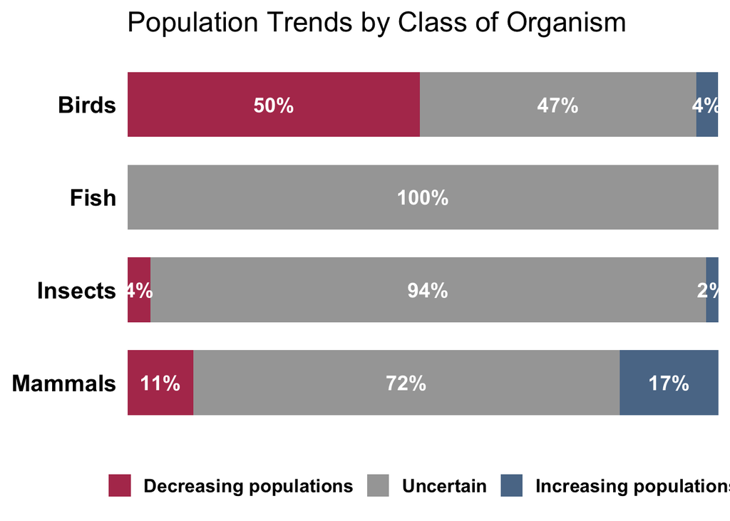

The plot above shows the estimated trend in relative abundance for different groups of animals in the WECA region:

- The dark lines represent the average (median) estimate.
- The shaded areas that are revealed when you hover your mouse cursor on a particular line show the 95% credible intervals (CIs).
- This area represents the possible trends that are 95% most likely, given the data and the model.

**Trends by Species**

[interactive chart not shown]

You can explore how different species are likely to be changing above:

1. Search for a species by name or select one from the drop-down boxes.
2. The plots below then update automatically:
- The left panel shows the estimated trend for that species across the whole region.
- The right panel shows the estimated trends at the sites where the species was observed.
- The shaded areas on both panels represent the 95% credible intervals (CIs) for the estimated trend.

*Note: the vertical axes are on the natural log scale.*

**Further Information**

### State of Nature Report (2026)

This analysis informed the West of England Nature Partnership’s recent State of Nature report. You can read [here](https://www.wenp.org.uk/state-of-nature) to find out more about biodiversity in the region.

### Methods

This analysis was based on over 74,000 systematically collected observations, each recording a count of individuals of a species at a location, between 2000 and 2025. Surveys included a measure of recorder effort (e.g. duration or distance covered) to account for biases in the recording process. As the map shows, records span the whole WECA region, giving confidence that trends are representative.

[interactive chart not shown]

Broken down by class of organism, the majority of records were birds, followed by insects, with fish, mammals and other taxa making up a smaller share.

Species abundance was modelled using Bayesian multilevel models in R, building on previous work by collaborators<sup>1,2</sup>. Counts were log-transformed, with year as the predictor and random effects allowing each species its own average abundance and trend over time. Survey effort was accounted for using an offset, and additional terms captured temporal and spatial autocorrelation (similarity between observations close together in time or location) — improving the reliability of estimates across species, effort levels, and locations.

Four models were used, one per group: birds (165 species), fish (8 species), insects (265 species), and mammals (18 species).

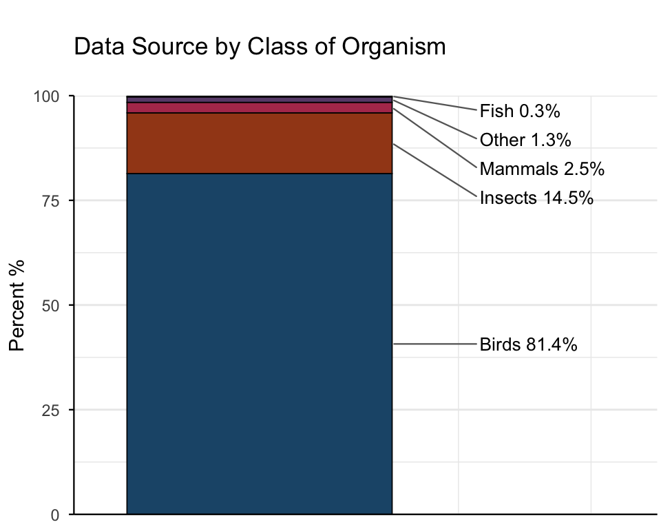

### Acknowledgements

We are very grateful to the following organisations and their volunteers, whose data is used in the analysis: the British Trust for Ornithology (BTO) for Breeding Bird Survey and Wetland Bird Survey data; the Bumblebee Conservation Trust and their BeeWalk project; Butterfly Conservation’s Big Butterfly Count and UK Butterfly Monitoring Scheme, with assistance from the Bristol Regional Environmental Records Centre; the Garden Moth Scheme; the National Bat Monitoring Programme (NBMP), which is run by the Bat Conservation Trust; the People’s Trust for Endangered Species (PTES) for their National Dormouse Monitoring Programme (NDMP) and Living with Mammals datasets; the Riverfly Partnership; Defra for data on freshwater fish and invertebrates; and the Rothamsted Insect Survey.

### References

1. Capdevila, Pol & O’Brien, Duncan & Marconi, Valentina & Johnson, Thomas & Freeman, Robin & McRae, Louise & Clements, Christopher. (2026). Halting predicted vertebrate declines requires tackling multiple drivers of biodiversity loss. Science Advances. 12. eadx7973. 10.1126/sciadv.adx7973.
2. Johnson, T.F., Beckerman, A.P., Childs, D.Z. et al. Revealing uncertainty in the status of biodiversity change. Nature 628, 788–794 (2024). https://doi.org/10.1038/s41586-024-07236-z